## Reproducible research

> “Reproducibility, also known as replicability and repeatability, is a major principle underpinning the scientific method. For the findings of a study to be reproducible means that results obtained by an experiment or an observational study or in a statistical analysis of a data set should be achieved again with a high degree of reliability when the study is replicated. … With a narrower scope, reproducibility has been introduced in computational sciences: Any results should be documented by making all data and code available in such a way that the computations can be executed again with identical results.”

### Project-oriented workflow: good practice

Properly managing data and other research outputs should starts at the beginning of your project. It should then and continue throughout!

To setup an RStudio `.RProj` project go to **Project** (top right) > **New Project** > **Create Project**

**Best-practice tips**

- Be organised: set up each each assignment/university course as a *project*
- Ensure your project is self-contained. A *project* is a folder that should contain all the relevant files and all paths should be relative to that *project*
- Always apply the 5 Cs: be **C**lear, **C**oncise, **C**onsistent, **C**orrect, and **C**onformant.
- Naming files should be descriptive and consistent!
- Include a README file that summarises your project’s structure
- Provide a detailed description of the data, data source(s), and how it will be used.
- Describe all the steps of data preprocessing.
- Provide a description and information about each new version of the data.
- Provide details about the software/code that is used for preprocessing the data.
- Include brief examples of how your code works.
- Generate a list of all scripts, how to run them, and in what order.
- When structuring your project directory consider the following:
  - Put code and data in separate subdirectories.
  - Plan to separate raw data from processed data.
  - An example of a well-structured directory
    - ProjectName/
      - README.MD
      - Dataset/
        - Raw Data/
        - Processed Data/
      - Analysis (or Code or Scripts)/
        - Data cleaning/
        - Data preprocessing/
      - Output/
        - Graphs
        - Tables

**Always start with a clean workspace** **Why?** *So your ex (code) can’t come and mess up your life!*

[figure not shown]

To ensure this go to **Tools** > **Global Options** and uncheck the highlighted options.

[figure not shown]

**⚠️Warning⚠️**

> If the first line of your R script is `setwd("C:\Users\jenny\path\that\only\I\have")` I will come into your office and SET YOUR COMPUTER ON FIRE 🔥. If the first line of your R script is `rm(list = ls())` I will come into your office and SET YOUR COMPUTER ON FIRE 🔥.

**Why?** Because, this is not reproducible, does **NOT** create a fresh `R` process, makes your script vulnerable, and it **will** come back to bite you.

### Version control with `git` and GitHub

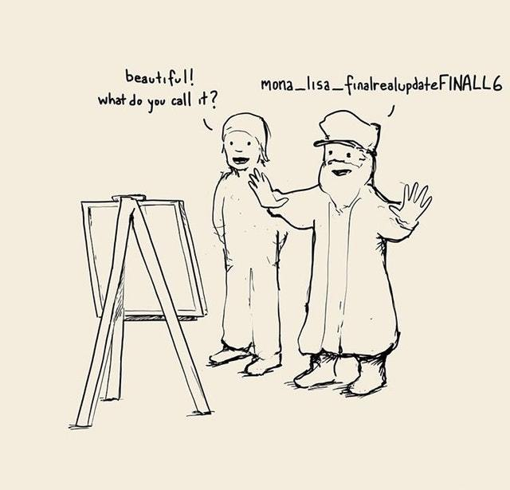

Git is a version control system that manages the evolution of a set of files, called a repository (repo), in a structured way (think of Word’s Track Changes). With Git you can track the changes you make to your project/code. You will **always** have a record of what you’ve worked on and can easily revert back to an older version if you make a mistake. GitHub is a hosting service that provides a home for your Git-based projects on the internet (think of Dropbox). In addition, GitHub offers functionality to use Git online via an easy-to-use interface. Both Git and GitHub can very easily be configured to work with RStudio.

Below are some key terms you will undoubtedly hear when delving into the git–GitHub world.

**Repository** (already mentioned) This where the work happens–think of it as your project folder. It should contain all of your project’s files etc.

**Cloning** A repository on GitHub is stored remotely in the cloud. To create a local copy of this repository you can clone it and use Git to sync the two.

**Committing** and **pushing** are how you can add the changes you made on your local machine to the remote repository in GitHub. You can make a commit when you have made milestone worthy changes to your project. You should also add a helpful commit message to remind future you, or your teammates, what the changes you made were (e.g., fixed the bug in my_function).

#### Setting up

1. Register an account with GitHub https://github.com. Choose the free option!
2. Make sure you’ve got the latest version of `R`

```r
R.version.string
```

```
## [1] "R version 4.1.2 (2021-11-01)"
```

3. Upgrade `RStudio` to the [new preview version](https://rstudio.com/products/rstudio/download/preview/) (*optional*)
4. Install git: follow [these instructions](https://happygitwithr.com/install-git.html)
5. [Get started](https://happygitwithr.com/hello-git.html)

#### Cloning a repository from `GitHub` using `RStudio`

[figure not shown]

3. Open `RStudio` in your local environment
4. Click `File`, `New Project`, `Version Control`, `Git`

[figure not shown]

[figure not shown]

5. Paste the repository URL and enter TAB to move to the `Project directory name` field.

[figure not shown]

6.Click `Create Project`. Your *Files* pane should now look similar to this

[figure not shown]

#### Commiting and pushing changes

1. Open a file from your project directory (here I’ve opened the file `README.md`). Note that the `Git` pane (top right) is empty

[figure not shown]

2. Make a change to your file and save. Now note that the `Git` pane (top right) is not empty:

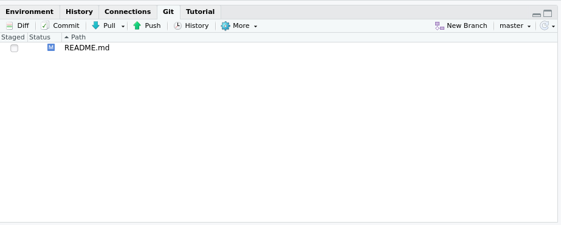

3. Check this file in the `Git` tab (it is now *staged* for commit).
4. Click the **Commit** button. A new pane will open. Changes made to the file will be highlighted (additions in green and deletions in red). Now write your self an **informative** message in the top right of this pop-up:

[figure not shown]

5. Click the **Commit** button below the message you’ve just written. A new pop up will let you know how things are going! You can then close both popups.

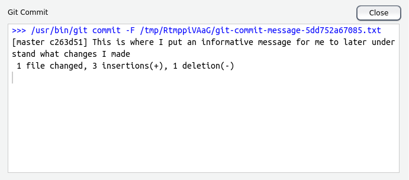

6. Now you’ll see RStudio has left you a little message in the `Git` tab, something similar to `Your branch is ahead of origin/master by 1 commit`. This means that you’ve made and commited your changes locally (i.e., on your computer) but you are yet to **push** these changes to GitHub.
7. To **push** to GitHub press the **Push** button,
8. A new pop up will let you know how things are going! You can then close this once it gives you the option to.

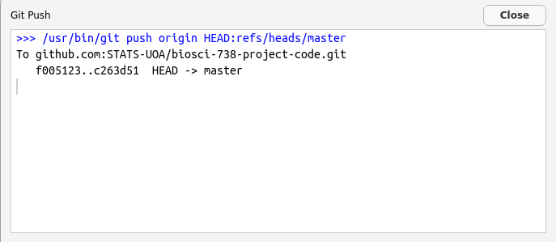